# Red Wine Quality EDA by Chip Reeves

# Introduction

The following is an analysis of almost 1600 samples of the Portuguese “Vinho Verde” wine. This particular set looks at red wines. I know aboslutely nothing about wine, so this seemed like a good dataset to explore.

# Univariate Plots Section

To begin the analysis, I calculated some basic summary statistics and histograms of the data. I noticed some variables had long tails, so I applied a log transformation to those variables and replotted the data.

```
##        X          fixed.acidity   volatile.acidity  citric.acid
##  Min.   :   1.0   Min.   : 4.60   Min.   :0.1200   Min.   :0.000
##  1st Qu.: 400.5   1st Qu.: 7.10   1st Qu.:0.3900   1st Qu.:0.090
##  Median : 800.0   Median : 7.90   Median :0.5200   Median :0.260
##  Mean   : 800.0   Mean   : 8.32   Mean   :0.5278   Mean   :0.271
##  3rd Qu.:1199.5   3rd Qu.: 9.20   3rd Qu.:0.6400   3rd Qu.:0.420
##  Max.   :1599.0   Max.   :15.90   Max.   :1.5800   Max.   :1.000
##  residual.sugar     chlorides       free.sulfur.dioxide
##  Min.   : 0.900   Min.   :0.01200   Min.   : 1.00
##  1st Qu.: 1.900   1st Qu.:0.07000   1st Qu.: 7.00
##  Median : 2.200   Median :0.07900   Median :14.00
##  Mean   : 2.539   Mean   :0.08747   Mean   :15.87
##  3rd Qu.: 2.600   3rd Qu.:0.09000   3rd Qu.:21.00
##  Max.   :15.500   Max.   :0.61100   Max.   :72.00
##  total.sulfur.dioxide    density             pH          sulphates
##  Min.   :  6.00       Min.   :0.9901   Min.   :2.740   Min.   :0.3300
##  1st Qu.: 22.00       1st Qu.:0.9956   1st Qu.:3.210   1st Qu.:0.5500
##  Median : 38.00       Median :0.9968   Median :3.310   Median :0.6200
##  Mean   : 46.47       Mean   :0.9967   Mean   :3.311   Mean   :0.6581
##  3rd Qu.: 62.00       3rd Qu.:0.9978   3rd Qu.:3.400   3rd Qu.:0.7300
##  Max.   :289.00       Max.   :1.0037   Max.   :4.010   Max.   :2.0000
##     alcohol         quality
##  Min.   : 8.40   Min.   :3.000
##  1st Qu.: 9.50   1st Qu.:5.000
##  Median :10.20   Median :6.000
##  Mean   :10.42   Mean   :5.636
##  3rd Qu.:11.10   3rd Qu.:6.000
##  Max.   :14.90   Max.   :8.000
```

Our dataset consists of 12 variables, and almost 1600 observations. The variable of interest is wine quality. This is the median of at least 3 evaluations made by wine experts. Each expert graded the wine quality between 0 (very bad) and 10 (very excellent).

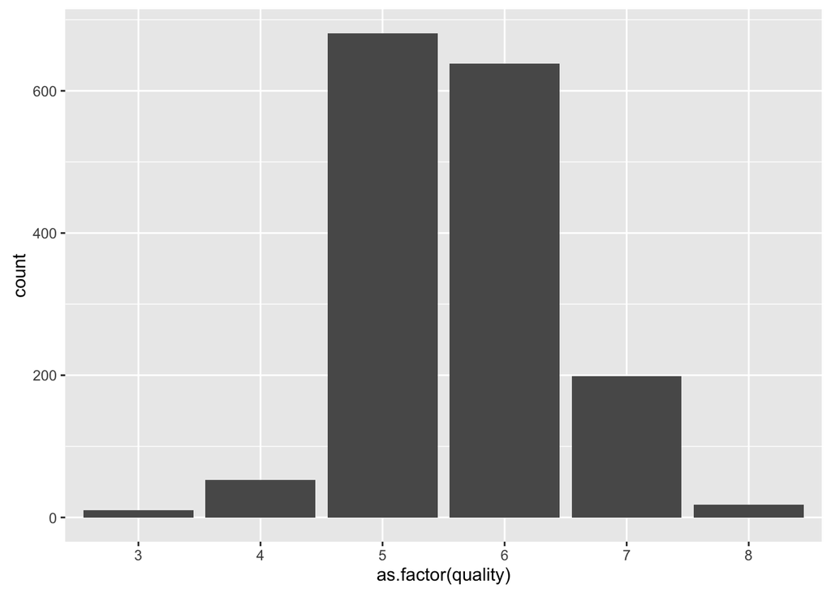

This graph shows a heavy concentration of “average” quality wines (ratings 5 and 6). The summary statistics also show the first quartile of ratings at 5 and the third quartile at 6, so about 75% of the observations are on “average” quality. This makes me wonder if the data set has been limited somehow. Where higher or lower quality wines removed? Or perhaps these wines are just “average” compared with those from other regions of the world.

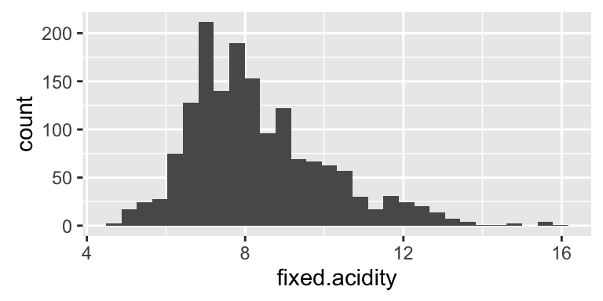

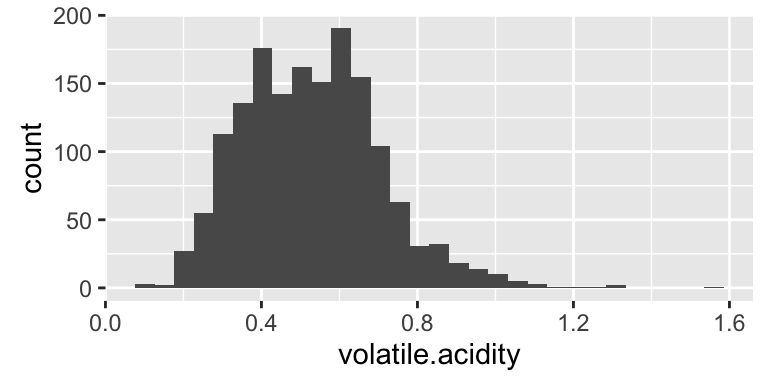

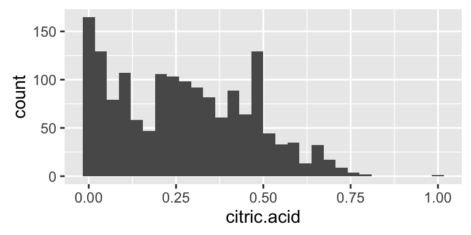

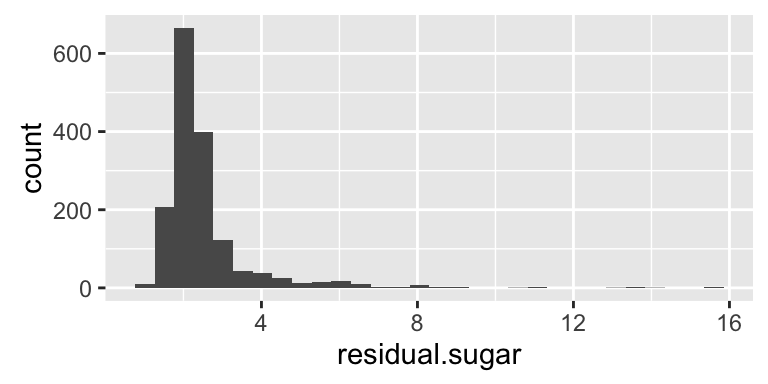

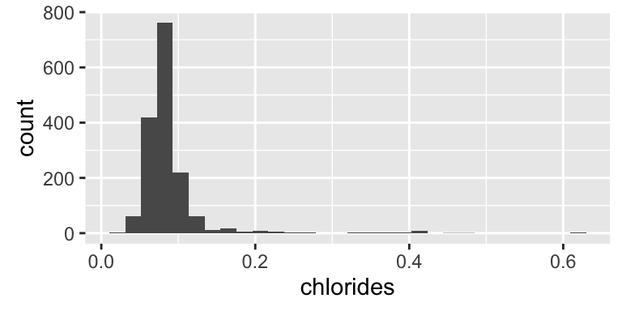

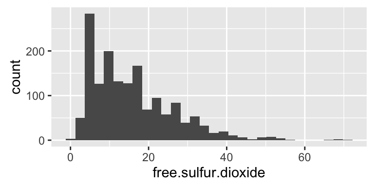

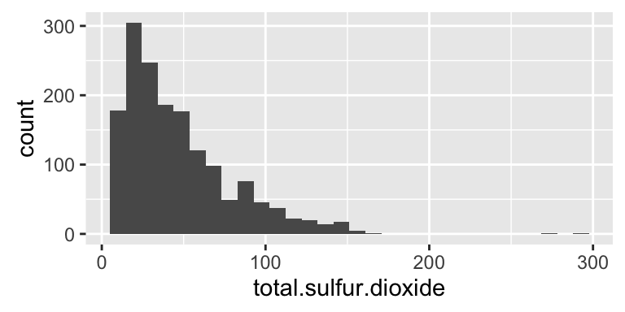

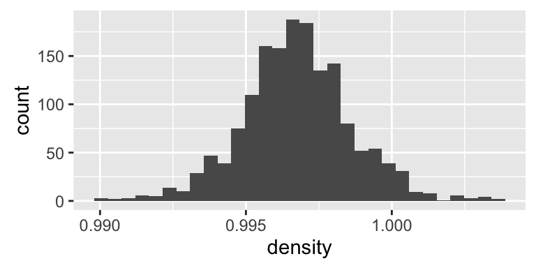

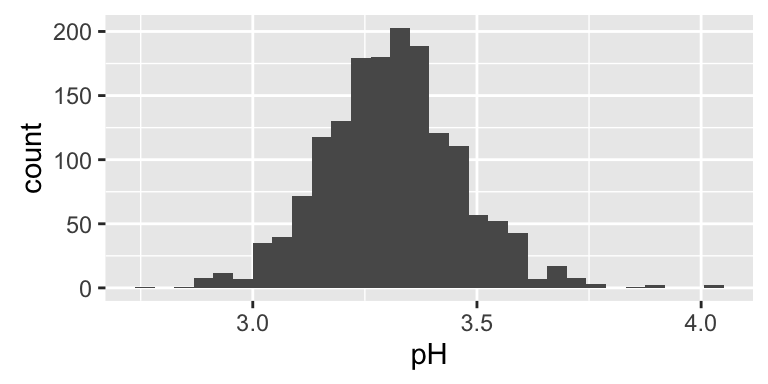

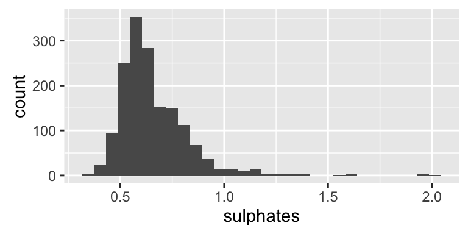

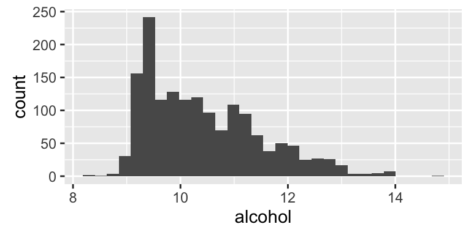

I am initially concerned with the narrow distribution of a couple of variables, residual sugar (generally between 1.9 and 2.6) and chlorides (generally between .07 and .09). It may be difficult to determine if these variables have any meaningful impact on wine quality. It is also interesting that density and pH have almost textbook normal distributions. Lastly, citric acid has an interesting distribution. The most common value is very close to zero, but there are plenty of observations at higher values as well. The second most common value is around .5, which is near the other end of the distribution.

Some of the variables have long tails. I will apply a log transformation on the x scale to better understand the distribution of each.

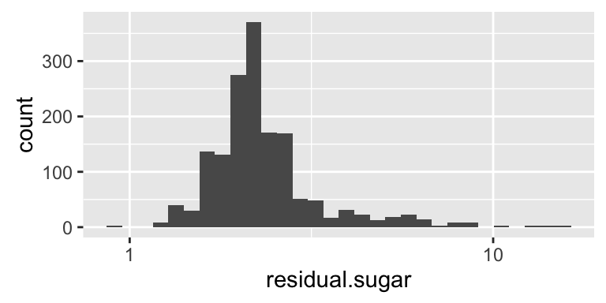

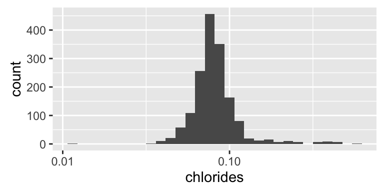

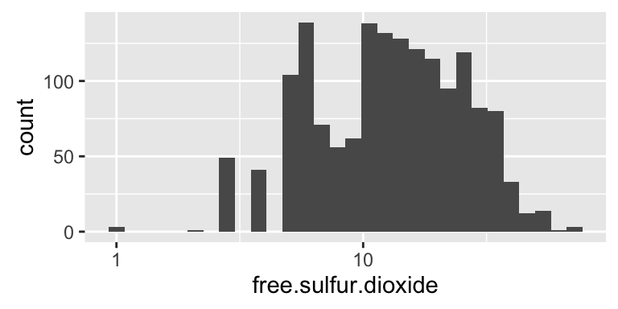

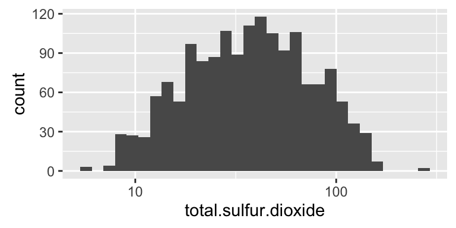

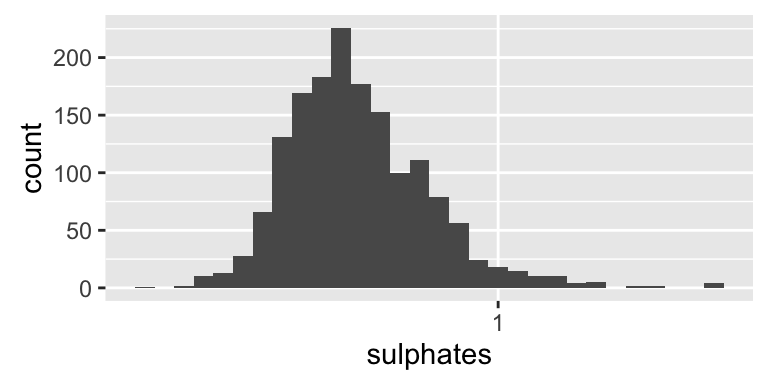

Residual sugar still has a skewed distribution. Free sulfur dioxide may be a bimodal distribution. The other variables appear more normally distributed when viewed under a log transformation.

# Univariate Analysis

### What is the structure of your dataset?

1599 observations. 11 attributes + 1 output attribute

### What is/are the main feature(s) of interest in your dataset?

Wine quality is the output of interest. It is on a 1-10 scale with 10 being good.

### What other features in the dataset do you think will help support your investigation into your feature(s) of interest?

11 physiochemical inputs that could possibly be used to predict wine quality are also captured.

### Did you create any new variables from existing variables in the dataset?

Yes. I used a log transformation to create new variables on long-tailed distributions on residual sugar, cholorides, free sulfur dioxide, total sulfur dioxide, and sulphates.

### Of the features you investigated, were there any unusual distributions? Did you perform any operations on the data to tidy, adjust, or change the form of the data? If so, why did you do this?

The data is clean and well structured otherwise and does not require additional wrangling beyond the optional transformations listed above.

# Bivariate Plots Section

With some very basic analysis of the frequencies of single variables completed, the next step in the analysis compared pairs of variables. The first grid of small multiples shows a correlation matrix above the horizontal, scatter plots below the horizontal, and histograms on the horizontal. This can quickly gives us clues for futher analysis.

Note: for this section I originally used the ggpairs function in the analysis. However, the equivalent plot from the psych package is presented in the Knit HMTL file for improved formatting.

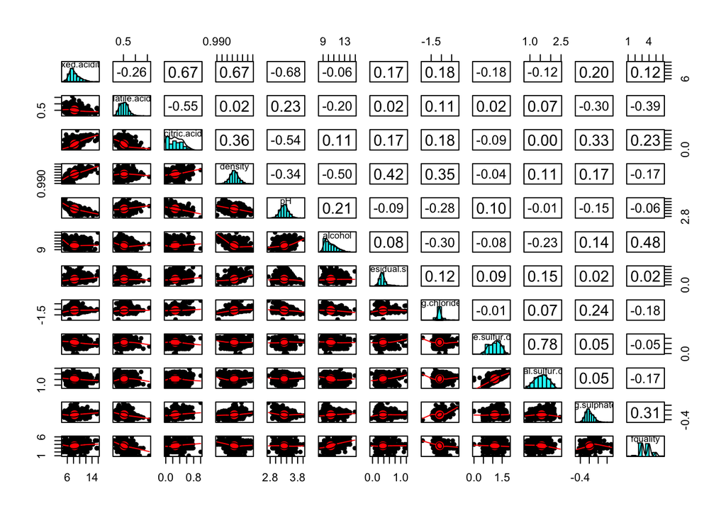

I then produced full-sized box plots for each variable to possibly indentify variables with strong affects on wine quality.

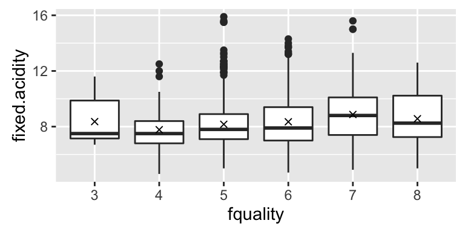

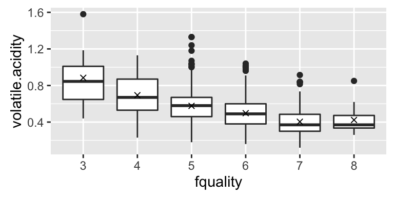

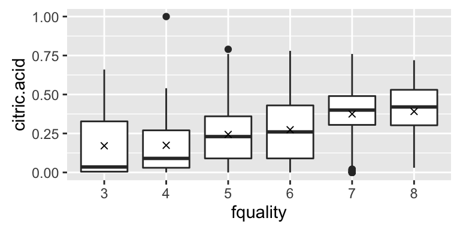

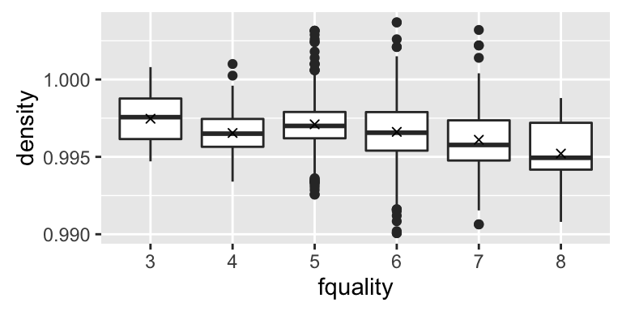

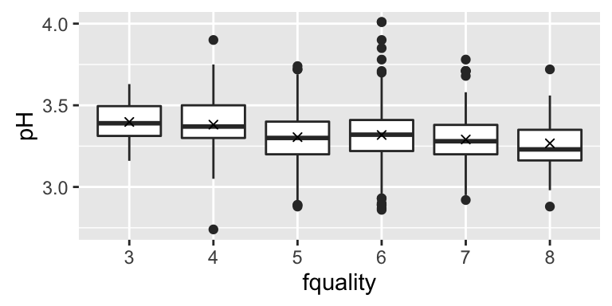

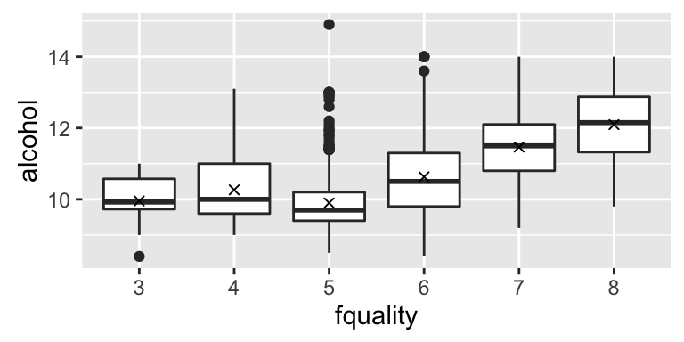

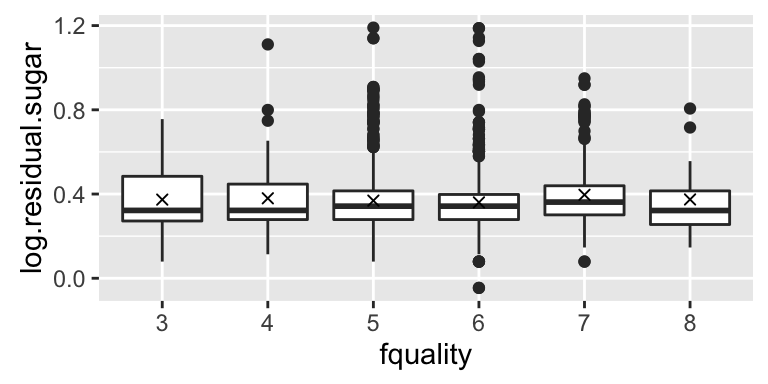

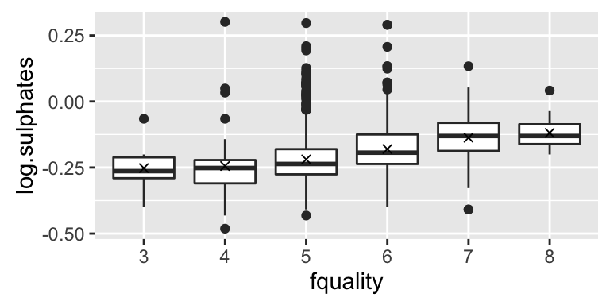

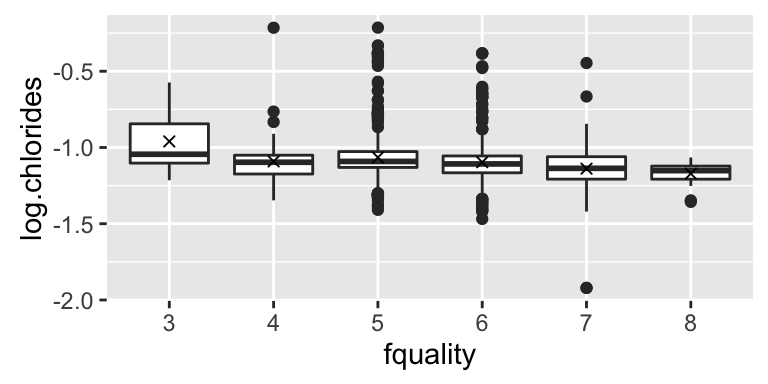

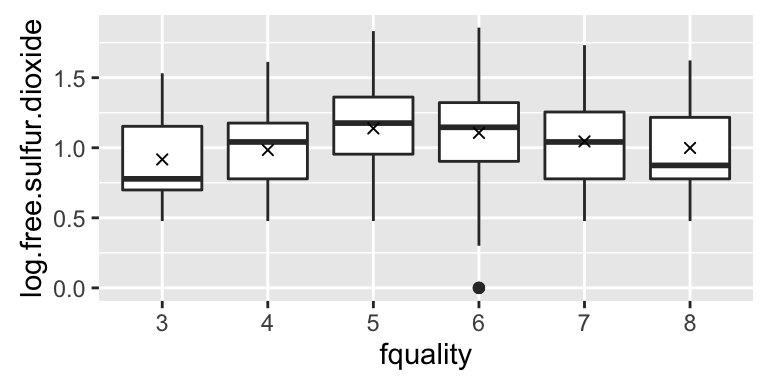

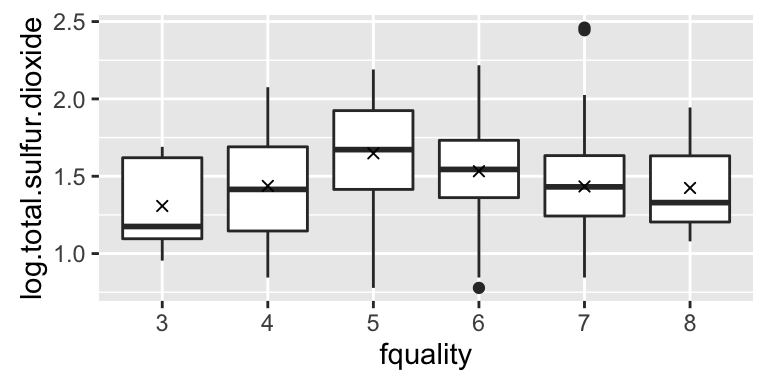

I like the distribution of citric acid, alcohol, and volatile acidity. The individual box plots indicate there may be relationships between each of these variables and wine quality. Wine quality generally increases as volatile acidity decreases. A correlation coefficient of -0.39 supports this belief. On the other hand, wine quality generally increases as alcohol and citric acid increase. Correlation coefficients of .48 and .23, respectfully, also support this observation.

# Bivariate Analysis

### Did you observe any interesting relationships between the other features (not the main feature(s) of interest)?

Yes, I’ll summarize them as follows.

##### Stronger Correlations above +/- .5

- Citric acid vs fixed acidity*
- Citric acid vs volatile acidity*
- Density vs fixed acidity
- pH vs fixed acidity*
- pH vs citric acid*
- total sulphur dioxide vs free sulphur dioxide*
- Some of these relationships (items marked *) are to be expected

#### Moderate Correlations above +/- .25

- Fixed acidity vs volatile acidity*
- Density vs Citric Acid
- Alcohol vs Density
- Residual Sugar vs Density
- Chlorides vs Density
- Chlorides vs pH
- Chorides vs Alcohol
- Sulphates vs Volatile Acidity
- Some of these relationships (items marked *) are to be expected

#### The supporting text gives several hints as to some interesting graphs.

- Pleasant wines have lower levels of acetic acid (volatile acidity).
- Fresh, fruity wines (pleasant) have higher levels of citric acid.
- Sulfur dioxide helps up to a certain level, but higher levels are unpleasant.
- - All of these are supported by the patterns in the quality boxplots.
- Density is related to alcohol, sugar, and salt content.
- - This is supported by the moderate values in the correlation matrix.

### What was the strongest relationship you found?

The highest correlation was between free sulfur dioxide and total sulfur dioxide. After taking the log10 of each, the correlation was .785. However, this is to be expected as both are measures of sulfur dioxide.